# House Prices Prediction

Kelompok 1

2024-06-03

**INTRODUCTION**  
Mintalah pembeli rumah untuk mendeskripsikan rumah impian mereka.  
Kemungkinan besar jawaban mereka bukan, ketinggian langit-langit, ruang bawah tanah, atau seberapa dekat dengan kereta api (transportasi umum). Namun, mereka cenderung mempertimbangkan harga daripada faktor lainnya.

Maka dari itu melalui dataset Hotel Prices, ingin diprediksi harga setiap rumah berdasarkan fitur-fitur yang dipilih & membuat model prediksi harga rumah.

*sumber dataset: https://www.kaggle.com/competitions/house-prices-advanced-regression-techniques*

**ATTRIBUTE YANG DIGUNAKAN UNTUK ANALISIS**  
SalePrice: Harga jual rumah.  
OverallQual: Kualitas keseluruhan material dan penyelesaian rumah.  
GrLivArea: Luas area hidup di atas tanah.  
GarageCars: Kapasitas mobil di garasi.  
TotalBsmtSF: Total luas basement.  
X1stFlrSF: Luas lantai pertama.  
FullBath: Jumlah kamar mandi.  
YearBuilt: Tahun dibangun.  
OverallCond: Kondisi keseluruhan rumah.  
Utilities: Tipe utilitas yang tersedia.  
Neighborhood: Lokasi lingkungan.  
ExterQual: Kualitas eksterior.  
ExterCond: Kondisi eksterior.  
Street: Jenis jalan akses ke properti.  
LotShape: Bentuk lot properti.

**PENYESUAIAN DATA**  
Pertama-tama kita lakukan Data Preparation untuk menyiapkan data agar data dapat diolah dengan baik.  
1. Mengubah Tipe Data: Mengonversi variabel kategorikal menjadi tipe faktor  
2. Menangani Nilai Hilang:  
- Numerik: Mengisi dengan median  
- Faktor: Menambahkan level eksplisit untuk nilai hilang

##DATA PREPARATION

```r
# Load necessary libraries
if (!require(tidyverse)) install.packages("tidyverse", dependencies = TRUE)
if (!require(caret)) install.packages("caret", dependencies = TRUE)
library(tidyverse)
library(caret)

# Read the dataset
house_data <- read.csv("House Prices.csv")

# Check the structure of the data
str(house_data)
```

```
## 'data.frame':    1460 obs. of  81 variables:
##  $ Id           : int  1 2 3 4 5 6 7 8 9 10 ...
##  $ MSSubClass   : int  60 20 60 70 60 50 20 60 50 190 ...
##  $ MSZoning     : chr  "RL" "RL" "RL" "RL" ...
##  $ LotFrontage  : int  65 80 68 60 84 85 75 NA 51 50 ...
##  $ LotArea      : int  8450 9600 11250 9550 14260 14115 10084 10382 6120 7420 ...
##  $ Street       : chr  "Pave" "Pave" "Pave" "Pave" ...
##  $ Alley        : chr  NA NA NA NA ...
##  $ LotShape     : chr  "Reg" "Reg" "IR1" "IR1" ...
##  $ LandContour  : chr  "Lvl" "Lvl" "Lvl" "Lvl" ...
##  $ Utilities    : chr  "AllPub" "AllPub" "AllPub" "AllPub" ...
##  $ LotConfig    : chr  "Inside" "FR2" "Inside" "Corner" ...
##  $ LandSlope    : chr  "Gtl" "Gtl" "Gtl" "Gtl" ...
##  $ Neighborhood : chr  "CollgCr" "Veenker" "CollgCr" "Crawfor" ...
##  $ Condition1   : chr  "Norm" "Feedr" "Norm" "Norm" ...
```

[output cut: 67 more lines]

```r
# Convert categorical variables to factors
categorical_vars <- c("MSSubClass", "MSZoning", "Street", "Alley", "LotShape", "LandContour", "Utilities", "LotConfig", "LandSlope",
                      "Neighborhood", "Condition1", "Condition2", "BldgType", "HouseStyle", "RoofStyle", "RoofMatl", "Exterior1st",
                      "Exterior2nd", "MasVnrType", "ExterQual", "ExterCond", "Foundation", "BsmtQual", "BsmtCond", "BsmtExposure",
                      "BsmtFinType1", "BsmtFinType2", "Heating", "HeatingQC", "CentralAir", "Electrical", "KitchenQual", "Functional",
                      "FireplaceQu", "GarageType", "GarageFinish", "GarageQual", "GarageCond", "PavedDrive", "PoolQC", "Fence",
                      "MiscFeature", "SaleType", "SaleCondition")

house_data[categorical_vars] <- lapply(house_data[categorical_vars], as.factor)

# Handle missing values
house_data <- house_data %>%
  mutate(across(where(is.numeric), ~ ifelse(is.na(.), median(., na.rm = TRUE), .))) %>%
  mutate(across(where(is.factor), ~ fct_explicit_na(.)))
# Summary of the cleaned data
summary(house_data)
```

```
##        Id           MSSubClass     MSZoning     LotFrontage
##  Min.   :   1.0   20     :536   C (all):  10   Min.   : 21.00
##  1st Qu.: 365.8   60     :299   FV     :  65   1st Qu.: 60.00
##  Median : 730.5   50     :144   RH     :  16   Median : 69.00
##  Mean   : 730.5   120    : 87   RL     :1151   Mean   : 69.86
##  3rd Qu.:1095.2   30     : 69   RM     : 218   3rd Qu.: 79.00
##  Max.   :1460.0   160    : 63                  Max.   :313.00
##                   (Other):262
##     LotArea        Street           Alley      LotShape  LandContour
##  Min.   :  1300   Grvl:   6   Grvl     :  50   IR1:484   Bnk:  63
##  1st Qu.:  7554   Pave:1454   Pave     :  41   IR2: 41   HLS:  50
##  Median :  9478               (Missing):1369   IR3: 10   Low:  36
##  Mean   : 10517                                Reg:925   Lvl:1311
##  3rd Qu.: 11602
##  Max.   :215245
##
##   Utilities      LotConfig    LandSlope   Neighborhood   Condition1
##  AllPub:1459   Corner : 263   Gtl:1382   NAmes  :225   Norm   :1260
##  NoSeWa:   1   CulDSac:  94   Mod:  65   CollgCr:150   Feedr  :  81
##                FR2    :  47   Sev:  13   OldTown:113   Artery :  48
##                FR3    :   4              Edwards:100   RRAn   :  26
##                Inside :1052              Somerst: 86   PosN   :  19
##                                          Gilbert: 79   RRAe   :  11
##                                          (Other):707   (Other):  15
##    Condition2     BldgType      HouseStyle   OverallQual      OverallCond
##  Norm   :1445   1Fam  :1220   1Story :726   Min.   : 1.000   Min.   :1.000
##  Feedr  :   6   2fmCon:  31   2Story :445   1st Qu.: 5.000   1st Qu.:5.000
##  Artery :   2   Duplex:  52   1.5Fin :154   Median : 6.000   Median :5.000
##  PosN   :   2   Twnhs :  43   SLvl   : 65   Mean   : 6.099   Mean   :5.575
##  RRNn   :   2   TwnhsE: 114   SFoyer : 37   3rd Qu.: 7.000   3rd Qu.:6.000
##  PosA   :   1                 1.5Unf : 14   Max.   :10.000   Max.   :9.000
##  (Other):   2                 (Other): 19
##    YearBuilt     YearRemodAdd    RoofStyle       RoofMatl     Exterior1st
##  Min.   :1872   Min.   :1950   Flat   :  13   CompShg:1434   VinylSd:515
##  1st Qu.:1954   1st Qu.:1967   Gable  :1141   Tar&Grv:  11   HdBoard:222
##  Median :1973   Median :1994   Gambrel:  11   WdShngl:   6   MetalSd:220
##  Mean   :1971   Mean   :1985   Hip    : 286   WdShake:   5   Wd Sdng:206
##  3rd Qu.:2000   3rd Qu.:2004   Mansard:   7   ClyTile:   1   Plywood:108
##  Max.   :2010   Max.   :2010   Shed   :   2   Membran:   1   CemntBd: 61
##                                               (Other):   2   (Other):128
```

[output cut: 89 more lines]

```
##  Gar2     :   2   Min.   :    0.00   Min.   : 1.000   Min.   :2006
##  Othr     :   2   1st Qu.:    0.00   1st Qu.: 5.000   1st Qu.:2007
##  Shed     :  49   Median :    0.00   Median : 6.000   Median :2008
##  TenC     :   1   Mean   :   43.49   Mean   : 6.322   Mean   :2008
##  (Missing):1406   3rd Qu.:    0.00   3rd Qu.: 8.000   3rd Qu.:2009
##                   Max.   :15500.00   Max.   :12.000   Max.   :2010
##
##     SaleType    SaleCondition    SalePrice
##  WD     :1267   Abnorml: 101   Min.   : 34900
##  New    : 122   AdjLand:   4   1st Qu.:129975
##  COD    :  43   Alloca :  12   Median :163000
##  ConLD  :   9   Family :  20   Mean   :180921
##  ConLI  :   5   Normal :1198   3rd Qu.:214000
##  ConLw  :   5   Partial: 125   Max.   :755000
##  (Other):   9
```

**KORELASI ANTAR VARIABLE**  
Lakukan Explorasi Data untuk mengetahui data apa saja yang dapat digunakan sebagai bahan Analisis  
1. Analisis Korelasi: Mengidentifikasi hubungan antara variabel numerik.  
2. Pair Plot: Memvisualisasikan hubungan antar variabel terpilih.

##EDA

```r
# Load additional libraries for visualization
if (!require(GGally)) install.packages("GGally", dependencies = TRUE)
```

```r
if (!require(ggcorrplot)) install.packages("ggcorrplot", dependencies = TRUE)
library(ggplot2)
library(GGally)
library(ggcorrplot)

# Verify column names
colnames(house_data)
```

```
##  [1] "Id"            "MSSubClass"    "MSZoning"      "LotFrontage"
##  [5] "LotArea"       "Street"        "Alley"         "LotShape"
##  [9] "LandContour"   "Utilities"     "LotConfig"     "LandSlope"
## [13] "Neighborhood"  "Condition1"    "Condition2"    "BldgType"
## [17] "HouseStyle"    "OverallQual"   "OverallCond"   "YearBuilt"
## [21] "YearRemodAdd"  "RoofStyle"     "RoofMatl"      "Exterior1st"
## [25] "Exterior2nd"   "MasVnrType"    "MasVnrArea"    "ExterQual"
## [29] "ExterCond"     "Foundation"    "BsmtQual"      "BsmtCond"
## [33] "BsmtExposure"  "BsmtFinType1"  "BsmtFinSF1"    "BsmtFinType2"
## [37] "BsmtFinSF2"    "BsmtUnfSF"     "TotalBsmtSF"   "Heating"
## [41] "HeatingQC"     "CentralAir"    "Electrical"    "X1stFlrSF"
## [45] "X2ndFlrSF"     "LowQualFinSF"  "GrLivArea"     "BsmtFullBath"
## [49] "BsmtHalfBath"  "FullBath"      "HalfBath"      "BedroomAbvGr"
## [53] "KitchenAbvGr"  "KitchenQual"   "TotRmsAbvGrd"  "Functional"
## [57] "Fireplaces"    "FireplaceQu"   "GarageType"    "GarageYrBlt"
## [61] "GarageFinish"  "GarageCars"    "GarageArea"    "GarageQual"
## [65] "GarageCond"    "PavedDrive"    "WoodDeckSF"    "OpenPorchSF"
## [69] "EnclosedPorch" "X3SsnPorch"    "ScreenPorch"   "PoolArea"
## [73] "PoolQC"        "Fence"         "MiscFeature"   "MiscVal"
## [77] "MoSold"        "YrSold"        "SaleType"      "SaleCondition"
## [81] "SalePrice"
```

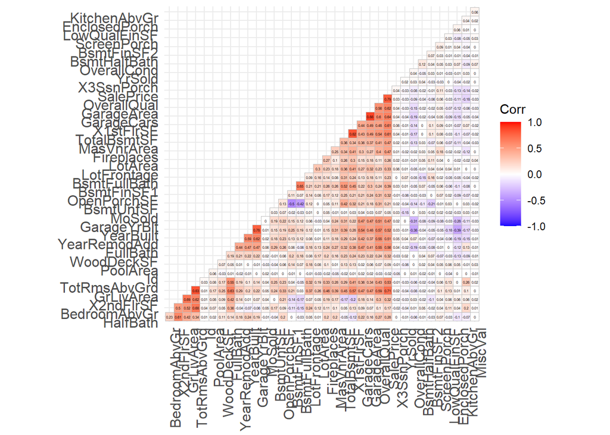

```r
# Correlation matrix for numerical variables (untuk mengidentifikasi hubungan antara variabel numerik)
numeric_vars <- house_data %>% select_if(is.numeric)
cor_matrix <- cor(numeric_vars, use = "complete.obs")

# Visualize correlation matrix
ggcorrplot::ggcorrplot(cor_matrix, lab = TRUE, lab_size = 1,
                       hc.order = TRUE, type = "lower") +
  theme(axis.text.x = element_text(angle = 90, vjust = 1, hjust = 1),
          axis.text.y = element_text(angle = 0, vjust = 1, hjust = 1))
```

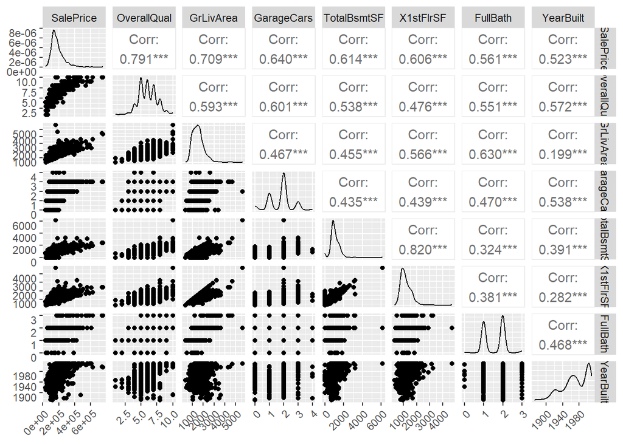

```r
# Check for correct column names and adjust if necessary (untuk memilih dan memverifikasi nama variabel yang diinginkan untuk analisis.)
selected_vars <- c("SalePrice", "OverallQual", "GrLivArea", "GarageCars", "TotalBsmtSF", "X1stFlrSF", "FullBath", "YearBuilt")
corrected_vars <- intersect(selected_vars, colnames(house_data))

# Pair plot for selected variables (untuk melihat hubungan berpasangan antara variabel yang dipilih.)
if (length(corrected_vars) >= 2) {
  ggpairs(house_data[corrected_vars]) +
    theme(axis.text.x = element_text(angle = 45, vjust = 1, hjust = 1),
          axis.text.y = element_text(angle = 0, vjust = 1, hjust = 1))
} else {
  cat("Not enough correct variables for pair plot. Please check the variable names.\n")
}
```

**ANALISIS DATA**  
Lakukan Visualisasi untuk tiap kolom yang akan digunakan sebagai bahan analisis

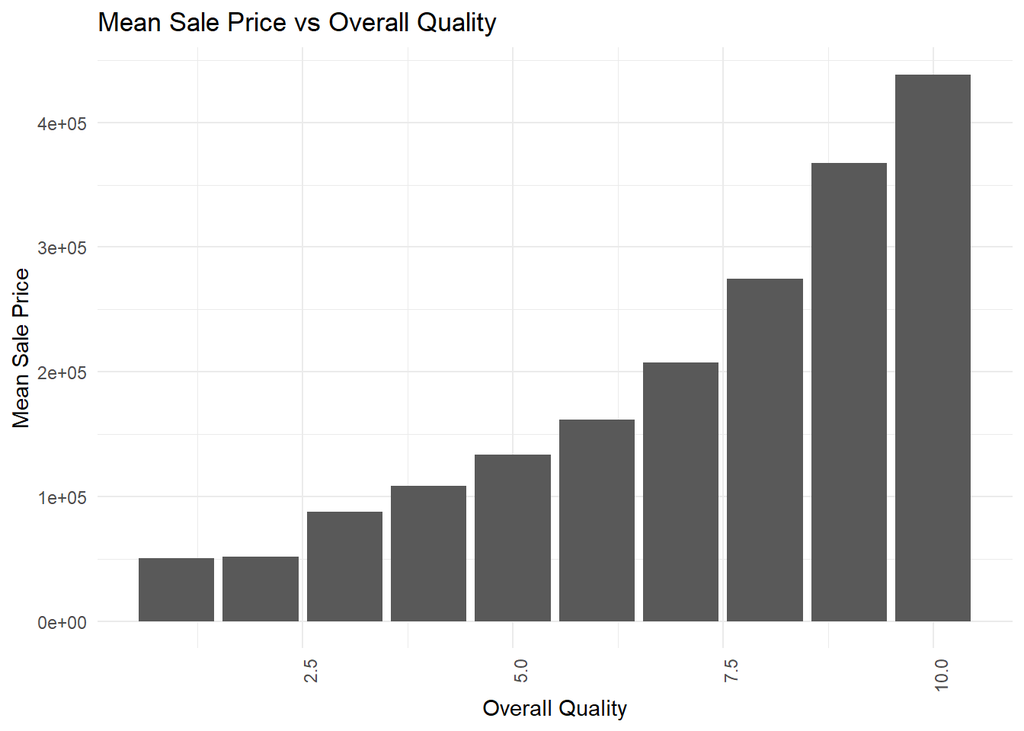

```r
# Barchart for between Sale Price and Overall Quality
house_summary <- house_data %>%
  group_by(OverallQual) %>%
  summarize(mean_SalePrice = mean(SalePrice, na.rm = TRUE))

colors <- rainbow(nrow(house_summary))

ggplot(house_summary, aes(x = OverallQual, y = mean_SalePrice)) +
  geom_col() +
  labs(title = "Mean Sale Price vs Overall Quality",
       x = "Overall Quality",
       y = "Mean Sale Price") +
  theme_minimal() +
 theme(axis.text.x = element_text(angle = 90, hjust = 1)) +
  scale_fill_manual(values = colors)
```

[figure not shown]

```r
# Scatter Plot for between Sale Price and Year Built
ggplot(house_data, aes(x = YearBuilt, y = SalePrice)) +
  geom_point() +
  labs(title = "YearBuilt vs Overall Quality") +
  theme_minimal()
```

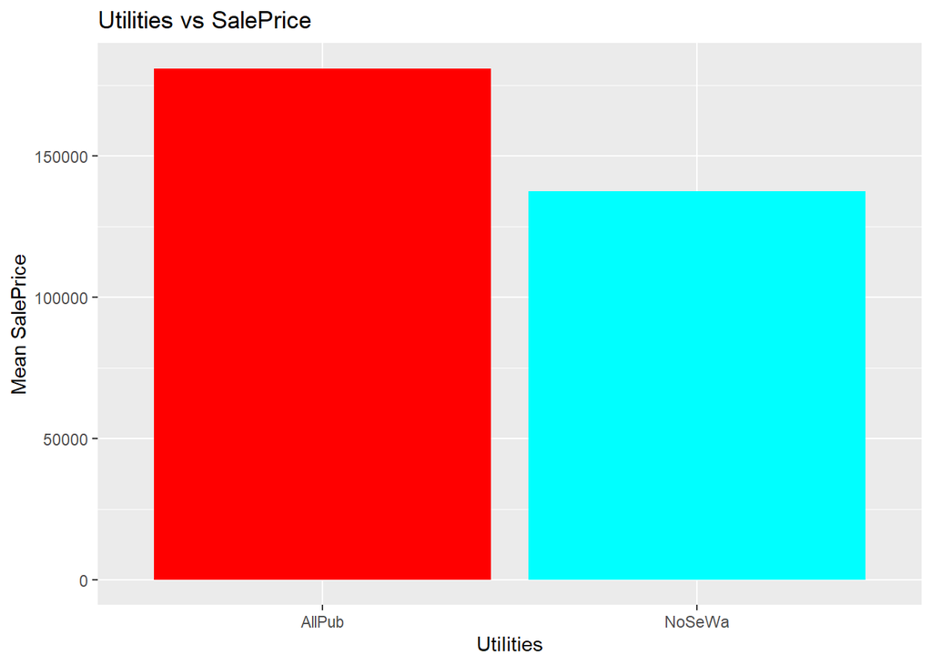

```r
# Barchart for between Sale Price and Utilities
aggregated_data <- aggregate(SalePrice ~ Utilities, data = house_data, mean)

colors <- rainbow(nrow(aggregated_data))

ggplot(aggregated_data, aes(x = Utilities, y = SalePrice)) +
  geom_bar(stat = "identity", fill= colors) +
  labs(title = "Utilities vs SalePrice", x = "Utilities", y = "Mean SalePrice")
```

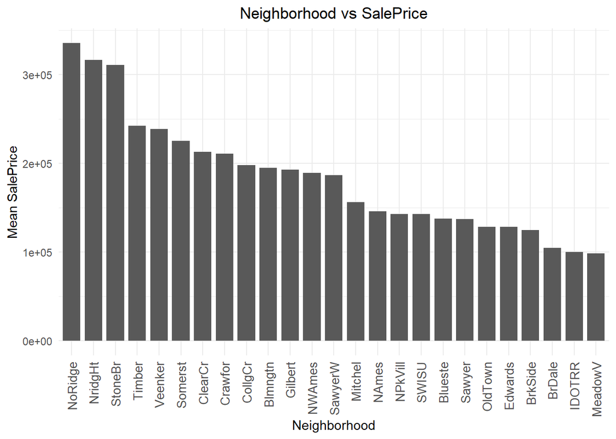

```r
# Barchart for Sale Price and Neighborhood
aggregated_data <- aggregate(SalePrice ~ Neighborhood, data = house_data, mean)

ggplot(aggregated_data, aes(x = reorder(Neighborhood, -SalePrice), y = SalePrice)) +
  geom_bar(stat = "identity", width = 0.8) +  # Adjust width of bars
  labs(title = "Neighborhood vs SalePrice", x = "Neighborhood", y = "Mean SalePrice") +
  theme_minimal() +
  theme(axis.text.x = element_text(angle = 90, hjust = 1, vjust = 0.5, size = 10),  # Rotate and adjust size of text
        plot.title = element_text(hjust = 0.5))  # Center the title
```

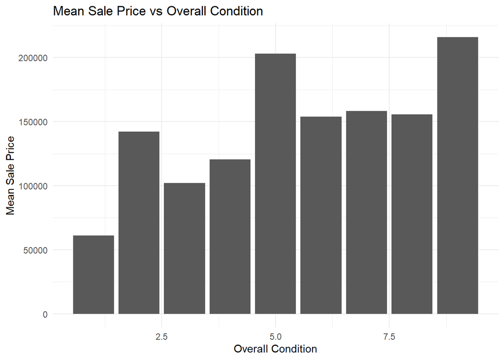

```r
# Barchart for between Sale Price and Overall Condition
house_summary <- house_data %>%
  group_by(OverallCond) %>%
  summarize(mean_SalePrice = mean(SalePrice, na.rm = TRUE))

colors <- rainbow(nrow(house_summary))

ggplot(house_summary, aes(x = OverallCond, y = mean_SalePrice)) +
  geom_col() +
  labs(title = "Mean Sale Price vs Overall Condition",
       x = "Overall Condition",
       y = "Mean Sale Price") +
  theme_minimal() +
scale_fill_manual(values = colors)
```

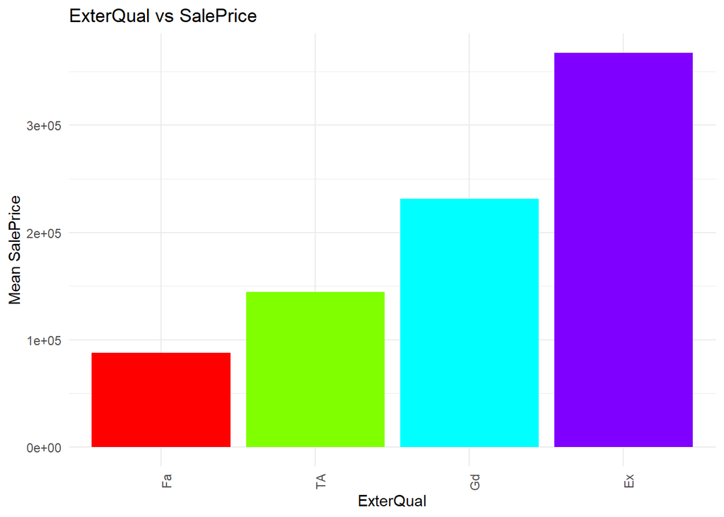

```r
# Barchart for between Sale Price and Exterior Quality

house_data$ExterQual <- factor(house_data$ExterQual, levels = c("Po", "Fa", "TA", "Gd", "Ex"))

aggregated_data <- aggregate(SalePrice ~ ExterQual, data = house_data, mean)

colors <- rainbow(nrow(aggregated_data))

ggplot(aggregated_data, aes(x = ExterQual, y = SalePrice)) +
  geom_bar(stat = "identity",fill= colors) +
  labs(title = "ExterQual vs SalePrice", x = "ExterQual", y = "Mean SalePrice") +
  theme_minimal() +
  theme(axis.text.x = element_text(angle = 90, hjust = 1))
```

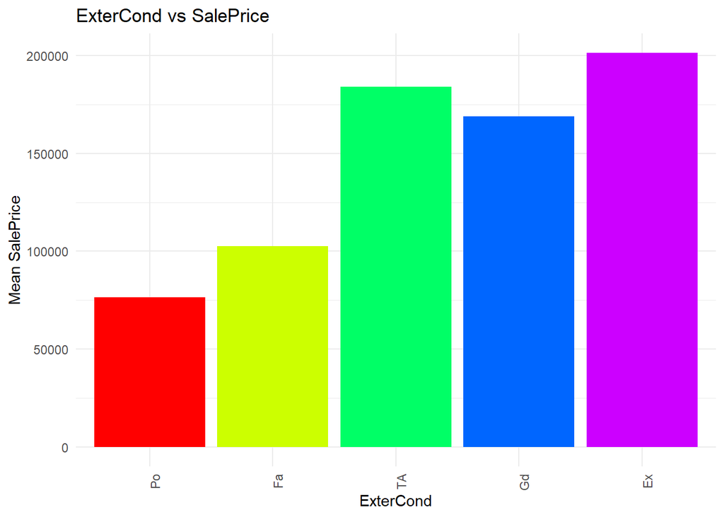

```r
# Barchart for between Sale Price and Exterior Condition
house_data$ExterCond <- factor(house_data$ExterCond, levels = c("Po", "Fa", "TA", "Gd", "Ex"))

aggregated_data <- aggregate(SalePrice ~ ExterCond, data = house_data, mean)

colors <- rainbow(nrow(aggregated_data))

ggplot(aggregated_data, aes(x = ExterCond, y = SalePrice)) +
  geom_bar(stat = "identity",fill= colors) +
  labs(title = "ExterCond vs SalePrice", x = "ExterCond", y = "Mean SalePrice") +
  theme_minimal() +
  theme(axis.text.x = element_text(angle = 90, hjust = 1))
```

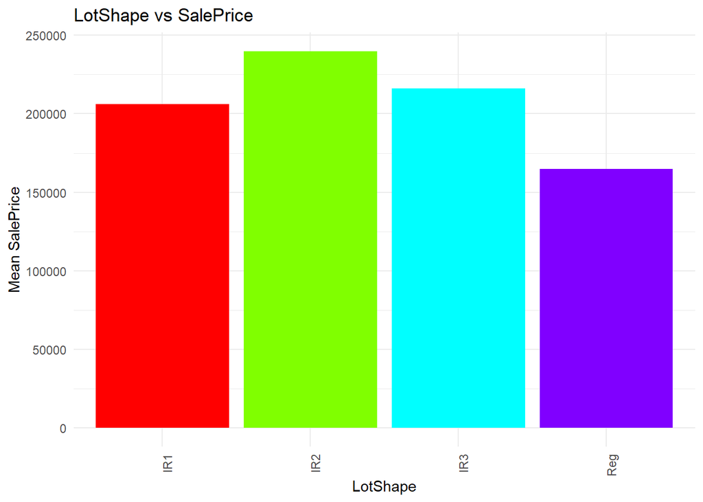

```r
# Barchart for between Sale Price and General shape of property

aggregated_data <- aggregate(SalePrice ~ LotShape, data = house_data, mean)

colors <- rainbow(nrow(aggregated_data))

ggplot(aggregated_data, aes(x = LotShape, y = SalePrice)) +
  geom_bar(stat = "identity",fill= colors) +
  labs(title = "LotShape vs SalePrice", x = "LotShape", y = "Mean SalePrice") +
  theme_minimal() +
  theme(axis.text.x = element_text(angle = 90, hjust = 1))
```

[figure not shown]

```r
# Barchart for between Sale Price and Type of road access to property
aggregated_data <- aggregate(SalePrice ~ Street, data = house_data, mean)

colors <- rainbow(nrow(aggregated_data))

ggplot(aggregated_data, aes(x = Street, y = SalePrice)) +
  geom_bar(stat = "identity",fill= colors) +
  labs(title = "Heating vs SalePrice", x = "Street", y = "Mean SalePrice") +
  theme_minimal() +
  theme(axis.text.x = element_text(angle = 90, hjust = 1))
```

Berdasarkan hasil visualisasi berbagai variable dengan variable SalePrice, dipilih variable yang paling berpengaruh:  
1. Kualitas Keseluruhan dan Harga Jual:  
Kualitas keseluruhan memiliki pengaruh besar terhadap harga jual.  
2. Tahun Dibangun dan Harga Jual:  
Rumah yang lebih baru cenderung lebih mahal.  
3. Lingkungan dan Harga Jual:  
Lokasi lingkungan menunjukkan variasi harga jual yang signifikan.

**MODEL PREDIKSI**  
Lakukan pembuatan Model untuk melihat faktor yang berpengaruh dengan harga jual Rumah

##Model building

```r
# Split data into training and testing sets
set.seed(123)
trainIndex <- createDataPartition(house_data$SalePrice, p = 0.8,
                                  list = FALSE,
                                  times = 1)
house_train <- house_data[ trainIndex,]
house_test  <- house_data[-trainIndex,]

#Make a linier regression model

#MODEL1
model1 <- lm(SalePrice ~ OverallQual + OverallCond + Utilities + Neighborhood + ExterQual + ExterCond + Street + LotShape,data = house_train)
summary(model1)
```

```
##
## Call:
## lm(formula = SalePrice ~ OverallQual + OverallCond + Utilities +
##     Neighborhood + ExterQual + ExterCond + Street + LotShape,
##     data = house_train)
##
## Residuals:
##     Min      1Q  Median      3Q     Max
## -181333  -21542   -1844   17228  244434
##
## Coefficients:
##                     Estimate Std. Error t value Pr(>|t|)
## (Intercept)           3885.6    44848.8   0.087 0.930974
## OverallQual          28143.8     1338.4  21.027  < 2e-16 ***
## OverallCond           1677.6     1224.5   1.370 0.170957
## UtilitiesNoSeWa     -63718.6    39573.4  -1.610 0.107647
## NeighborhoodBlueste -12252.7    29428.1  -0.416 0.677224
## NeighborhoodBrDale  -32314.8    15126.3  -2.136 0.032867 *
## NeighborhoodBrkSide    305.9    12228.3   0.025 0.980044
## NeighborhoodClearCr  56356.5    13281.9   4.243 2.39e-05 ***
## NeighborhoodCollgCr  18496.6    10701.1   1.728 0.084174 .
## NeighborhoodCrawfor  41447.5    12327.5   3.362 0.000799 ***
## NeighborhoodEdwards   4487.2    11639.2   0.386 0.699920
## NeighborhoodGilbert  12953.8    11507.8   1.126 0.260551
## NeighborhoodIDOTRR  -15649.6    13006.3  -1.203 0.229138
## NeighborhoodMeadowV  -6937.1    15570.4  -0.446 0.656020
## NeighborhoodMitchel  15445.9    12099.4   1.277 0.202013
## NeighborhoodNAmes    11382.9    11096.7   1.026 0.305212
## NeighborhoodNoRidge  96642.3    12100.5   7.987 3.39e-15 ***
## NeighborhoodNPkVill  -7953.5    20323.4  -0.391 0.695615
## NeighborhoodNridgHt  65085.8    11505.9   5.657 1.95e-08 ***
## NeighborhoodNWAmes   23486.8    11868.3   1.979 0.048064 *
## NeighborhoodOldTown  -9850.4    11505.5  -0.856 0.392099
## NeighborhoodSawyer   10925.7    12034.9   0.908 0.364156
## NeighborhoodSawyerW  21747.2    11580.5   1.878 0.060651 .
## NeighborhoodSomerst  26638.8    11115.2   2.397 0.016709 *
## NeighborhoodStoneBr  76113.1    13939.6   5.460 5.84e-08 ***
## NeighborhoodSWISU     9958.4    13912.0   0.716 0.474256
## NeighborhoodTimber   44052.0    12807.9   3.439 0.000604 ***
## NeighborhoodVeenker  50718.0    15629.4   3.245 0.001209 **
## ExterQualTA         -11029.8    12684.2  -0.870 0.384721
## ExterQualGd           2141.1    13422.8   0.160 0.873296
## ExterQualEx          57167.3    15515.9   3.684 0.000240 ***
## ExterCondFa         -19560.4    40106.4  -0.488 0.625848
## ExterCondTA         -10169.3    39580.9  -0.257 0.797284
## ExterCondGd          -7480.6    39863.7  -0.188 0.851181
## ExterCondEx         -17463.4    46298.7  -0.377 0.706104
## StreetPave           -4448.4    19611.4  -0.227 0.820597
## LotShapeIR2          13670.1     6899.0   1.981 0.047782 *
## LotShapeIR3            584.6    14095.4   0.041 0.966922
## LotShapeReg          -8758.2     2680.7  -3.267 0.001119 **
## ---
## Signif. codes:  0 '***' 0.001 '**' 0.01 '*' 0.05 '.' 0.1 ' ' 1
##
## Residual standard error: 38680 on 1130 degrees of freedom
## Multiple R-squared:  0.7507, Adjusted R-squared:  0.7423
## F-statistic: 89.52 on 38 and 1130 DF,  p-value: < 2.2e-16
```

```r
# Predictions on the test set
predictions <- predict(model1, house_test)
RMSE(predictions, house_test$SalePrice)
```

```
## [1] 49583.86
```

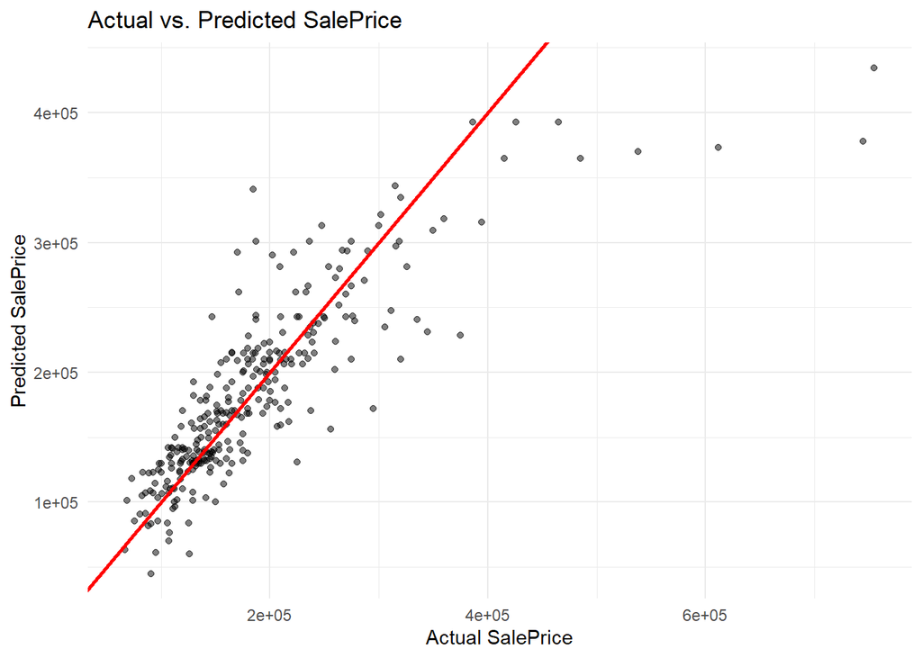

```r
#Make the Visualization with to compare the Actual Sale Price and Predicted SalePrice
ggplot(house_test, aes(x = SalePrice, y = predictions)) +
  geom_point(alpha = 0.5) +
  geom_abline(intercept = 0, slope = 1, color = 'red', size = 1) +
  labs(x = 'Actual SalePrice', y = 'Predicted SalePrice', title = 'Actual vs. Predicted SalePrice') +
  theme_minimal()
```

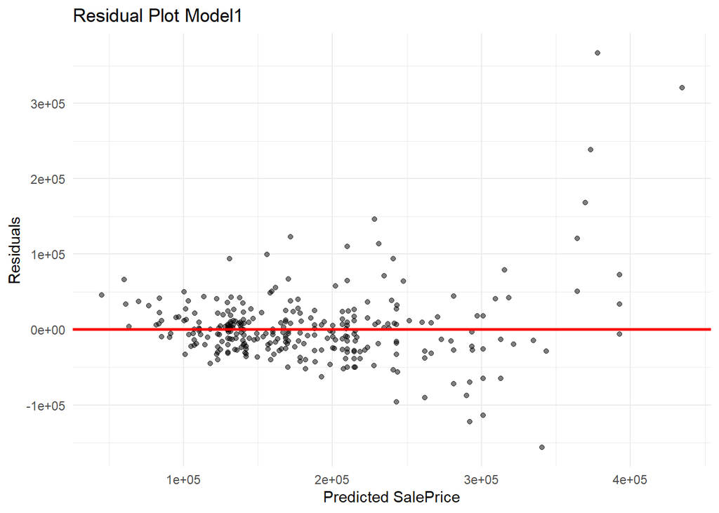

```r
# Make the Visualization residual plot
residuals <- house_test$SalePrice - predictions
ggplot(house_test, aes(x = predictions, y = residuals)) +
  geom_point(alpha = 0.5) +
  geom_hline(yintercept = 0, color = 'red', size = 1) +
  labs(x = 'Predicted SalePrice', y = 'Residuals', title = 'Residual Plot Model1') +
  theme_minimal()
```

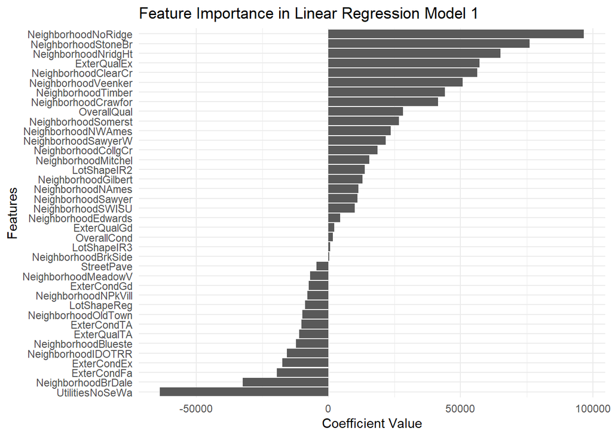

```r
feature_importance <- as.data.frame(coef(model1))
colnames(feature_importance) <- c("Coefficient")
feature_importance$Feature <- rownames(feature_importance)
feature_importance <- feature_importance[-1, ]
feature_importance <- feature_importance[order(abs(feature_importance$Coefficient), decreasing = TRUE), ]

# Make bar chart of feature importance
ggplot(feature_importance, aes(x = reorder(Feature, Coefficient), y = Coefficient)) +
  geom_bar(stat = 'identity') +
  labs(x = 'Features', y = 'Coefficient Value', title = 'Feature Importance in Linear Regression Model 1') +
  coord_flip() +
  theme_minimal()
```

```r
#MODEL2
#Make a another model that we eliminated OverallCond and LotShape
model2 <- lm(SalePrice ~ OverallQual + Utilities + Neighborhood + ExterQual + ExterCond + Street,data = house_train,method="qr")
summary(model2)
```

```
##
## Call:
## lm(formula = SalePrice ~ OverallQual + Utilities + Neighborhood +
##     ExterQual + ExterCond + Street, data = house_train, method = "qr")
##
## Residuals:
##     Min      1Q  Median      3Q     Max
## -177900  -21891   -1561   17628  242632
##
## Coefficients:
##                     Estimate Std. Error t value Pr(>|t|)
## (Intercept)             4310      45138   0.095 0.923941
## OverallQual            28521       1341  21.262  < 2e-16 ***
## UtilitiesNoSeWa       -58496      39818  -1.469 0.142089
## NeighborhoodBlueste   -10716      29626  -0.362 0.717638
## NeighborhoodBrDale    -30576      15219  -2.009 0.044759 *
## NeighborhoodBrkSide     5314      12172   0.437 0.662545
## NeighborhoodClearCr    66248      13192   5.022 5.93e-07 ***
## NeighborhoodCollgCr    23921      10702   2.235 0.025596 *
## NeighborhoodCrawfor    48113      12217   3.938 8.71e-05 ***
## NeighborhoodEdwards     8082      11660   0.693 0.488389
## NeighborhoodGilbert    22330      11328   1.971 0.048941 *
## NeighborhoodIDOTRR    -12165      13028  -0.934 0.350634
## NeighborhoodMeadowV    -4861      15658  -0.310 0.756303
## NeighborhoodMitchel    20529      12094   1.697 0.089890 .
## NeighborhoodNAmes      16428      11071   1.484 0.138102
## NeighborhoodNoRidge   103710      12058   8.601  < 2e-16 ***
## NeighborhoodNPkVill    -4454      20442  -0.218 0.827573
## NeighborhoodNridgHt    68450      11528   5.938 3.84e-09 ***
## NeighborhoodNWAmes     29625      11829   2.504 0.012404 *
## NeighborhoodOldTown    -5895      11464  -0.514 0.607177
## NeighborhoodSawyer     17240      11978   1.439 0.150348
## NeighborhoodSawyerW    25845      11609   2.226 0.026191 *
## NeighborhoodSomerst    29457      11174   2.636 0.008499 **
## NeighborhoodStoneBr    83155      13904   5.981 2.97e-09 ***
## NeighborhoodSWISU      14096      13951   1.010 0.312529
## NeighborhoodTimber     50342      12772   3.942 8.59e-05 ***
## NeighborhoodVeenker    60946      15540   3.922 9.31e-05 ***
## ExterQualTA           -11802      12662  -0.932 0.351513
## ExterQualGd             1993      13418   0.149 0.881924
## ExterQualEx            58278      15537   3.751 0.000185 ***
## ExterCondFa           -22981      40141  -0.573 0.567089
## ExterCondTA           -11097      39488  -0.281 0.778752
## ExterCondGd            -5972      39631  -0.151 0.880243
## ExterCondEx           -15569      45753  -0.340 0.733707
## StreetPave             -6886      19719  -0.349 0.727015
## ---
## Signif. codes:  0 '***' 0.001 '**' 0.01 '*' 0.05 '.' 0.1 ' ' 1
##
## Residual standard error: 38960 on 1134 degrees of freedom
## Multiple R-squared:  0.7462, Adjusted R-squared:  0.7385
## F-statistic: 98.04 on 34 and 1134 DF,  p-value: < 2.2e-16
```

```r
# Predictions on the test set
predictions2 <- predict(model2, house_test)
RMSE(predictions2, house_test$SalePrice)
```

```
## [1] 49753.79
```

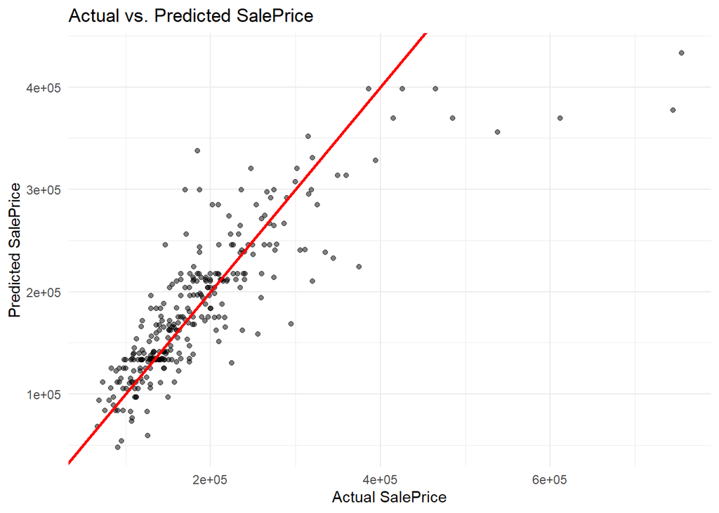

```r
#Make the Visualization with to compare the Actual Sale Price and Predicted SalePrice
ggplot(house_test, aes(x = SalePrice, y = predictions2)) +
  geom_point(alpha = 0.5) +
  geom_abline(intercept = 0, slope = 1, color = 'red', size = 1) +
  labs(x = 'Actual SalePrice', y = 'Predicted SalePrice', title = 'Actual vs. Predicted SalePrice') +
  theme_minimal()
```

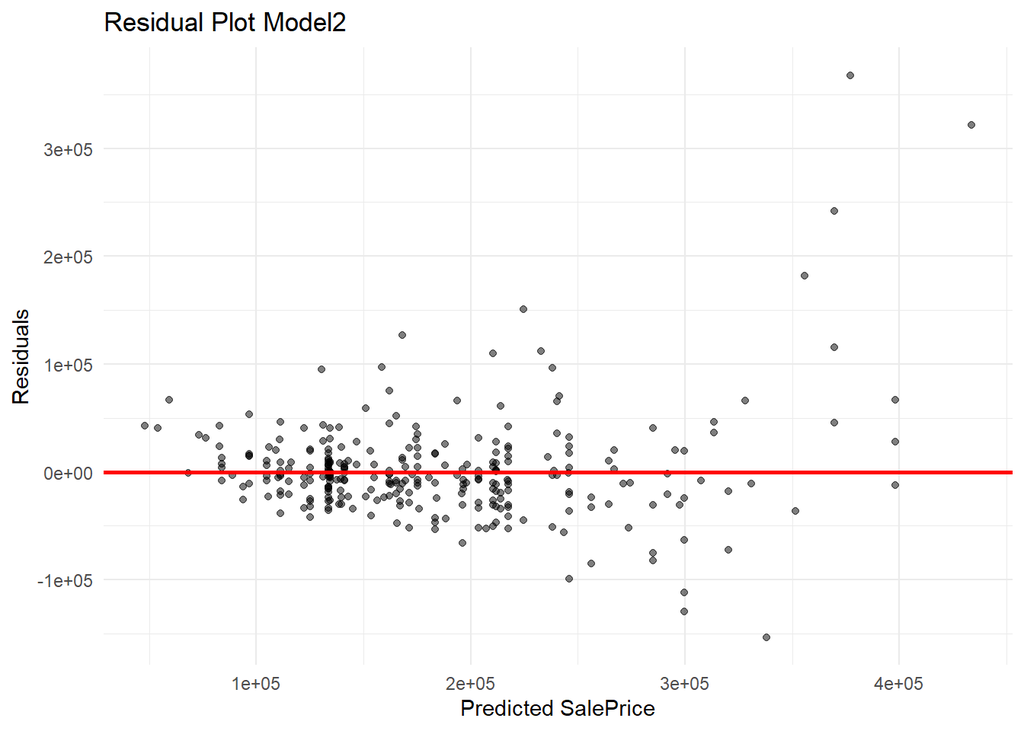

```r
# Make the Visualization residual plot
residuals <- house_test$SalePrice - predictions2
ggplot(house_test, aes(x = predictions2, y = residuals)) +
  geom_point(alpha = 0.5) +
  geom_hline(yintercept = 0, color = 'red', size = 1) +
  labs(x = 'Predicted SalePrice', y = 'Residuals', title = 'Residual Plot Model2') +
  theme_minimal()
```

[figure not shown]

```r
feature_importance2 <- as.data.frame(coef(model2))
colnames(feature_importance2) <- c("Coefficient")
feature_importance2$Feature <- rownames(feature_importance2)
feature_importance2 <- feature_importance[-1, ]
feature_importance2 <- feature_importance2[order(abs(feature_importance$Coefficient), decreasing = TRUE), ]
feature_importance2 <- feature_importance[-1, ]
feature_importance2 <- na.omit(feature_importance2)

# Make bar chart of feature importance
ggplot(feature_importance2, aes(x = reorder(Feature, Coefficient), y = Coefficient)) +
  geom_bar(stat = 'identity') +
  labs(x = 'Features', y = 'Coefficient Value', title = 'Feature Importance in Linear Regression Model 2') +
  coord_flip() +
  theme_minimal()
```

Berdasarkan feature importance, variabel Neighborhood, OverallQual, dan ExterQual menunjukkan pengaruh yang signifikan terhadap harga jual rumah dalam kedua model.

Pemilihan Model Terbaik:  
Membandingkan RMSE (Root Mean Squared Error) dari kedua model.  
Model dengan RMSE lebih rendah dipilih sebagai model terbaik.  
RMSE Model 1 = 49583.86  
RMSE Model 2 = 49753.79

**HASIL ANALISIS**  
1. Model 1 direkomendasikan sebagai model terbaik untuk memprediksi harga jual rumah dalam kasus ini.

**KESIMPULAN**  
Faktor-faktor utama yang mempengaruhi harga rumah:

1. Kualitas Keseluruhan (OverallQual): kualitas material dan hasil akhir rumah secara keseluruhan.

2. Kualitas Eksterior (ExterQual): kualitas bahan dan hasil akhir eksterior rumah.
3. Lingkungan (Neighborhood): Lokasi rumah sangat berpengaruh terhadap nilai jual. Lingkungan yang lebih baik cenderung memiliki harga jual yang lebih tinggi.
4. Tahun Dibangun (YearBuilt): Rumah yang dibangun lebih baru cenderung memiliki harga jual yang lebih tinggi karena kondisi yang lebih baik dan fitur yang lebih modern.

**INSIGHT**  
1. Renovasi untuk Meningkatkan Kualitas:  
Fokus pada peningkatan kualitas keseluruhan dan eksterior.

2. Investasi di Lokasi Strategis:  
   Memilih lokasi dengan permintaan tinggi.
3. Rumah baru/Renovasi:  
   Pembangunan atau renovasi rumah untuk tampilan dan fungsionalitas yang lebih modern.

**ACTIONABLE INSIGHT**  
1. Peningkatan kualitas:  
Renovasi untuk meningkatkan kualitas rumah.

2. Pemilihan lokasi:  
   Investasi di lingkungan yang strategis dan populer.
3. Rumah baru atau renovasi:  
   Menarik pembeli dengan rumah baru atau yang telah direnovasi.